# Final project

2022-11-23

Thousands of new songs are released every year but very few make it to the top records. We decided to embark on a journey to discover what are the different characteristics of hit songs to help artists maximize their chances of launching a successful song.

We started with with all the songs that have been on the Top 200 Weekly (Global) charts of Spotify in 2020 & 2021 (https://www.kaggle.com/datasets/sashankpillai/spotify-top-200-charts-20202021). The dataset contains features such as danceability, liveness, energy, loudness, chord etc.

```r
#loading data and fixing column names using janitor
spotify_data <- vroom("data/spotify.csv", show_col_types = FALSE) %>%
  clean_names()
```

```r
#check NA values for the release date
sum(is.na(spotify_data$`Release Date`))
```

```
## [1] 0
```

```r
#Clean data
spotify_data_clean <- spotify_data %>%
  dplyr::select(-index) %>%  #remove index column
  dplyr::select(-artist_followers,-streams, -song_id, everything()) %>%#move some not-so-important variables to the end.
  mutate(
    release_date = mdy(release_date),#convert release date from char to date format
    release_month = month(release_date, label=TRUE, abbr = TRUE),
    release_day = day(release_date),
    duration_min = duration_ms / 60000
  ) %>%
  filter(!is.na(release_date))#17 values had a different format than month-day-year. We remove these and the previous NA values.
```

We first want to look at the most popular genre. The graph shows that dance pop is the most popular genre among the songs.

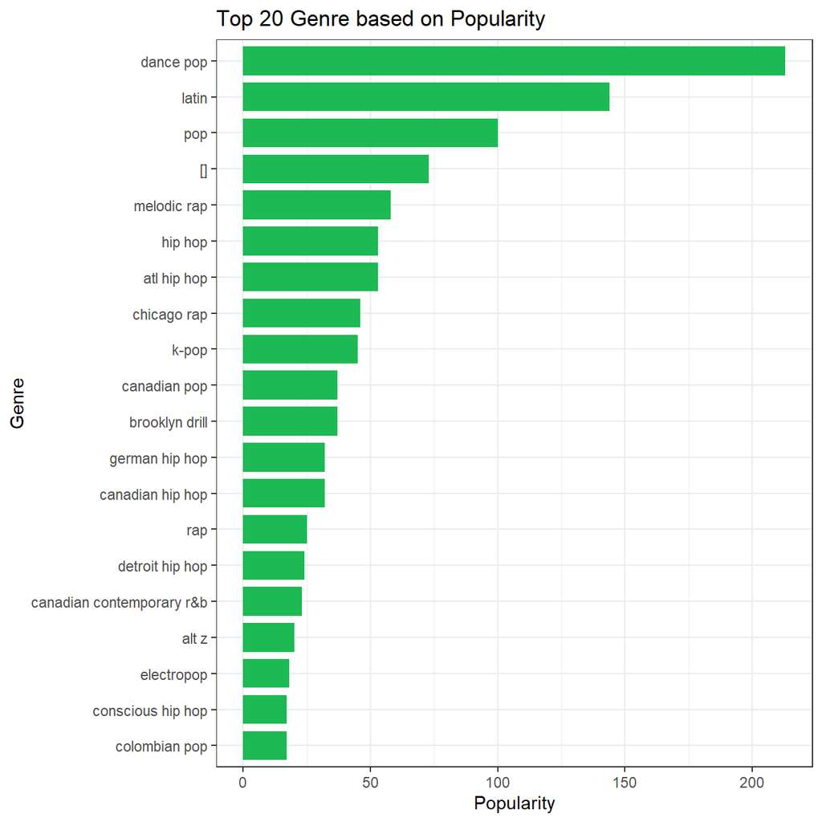

```r
#finding the top 20 genre
data1 <- spotify_data_clean %>%
  group_by(genre) %>%
  summarise(occurances = n()) %>%
  slice_max(order_by = occurances, n=20)

ggplot(data1, aes(y=fct_reorder(genre,(occurances)), x=occurances)) +
  geom_col(stat = 'identity',
           width=0.8,
           fill = "#1db954")+
  theme(legend.position = "none") +
  labs(title = "Top 20 Genre based on Popularity",
       y = "Genre",
       x="Popularity")+
  theme_bw()
```

Next we look at the most popular artist which is Taylor Swift.

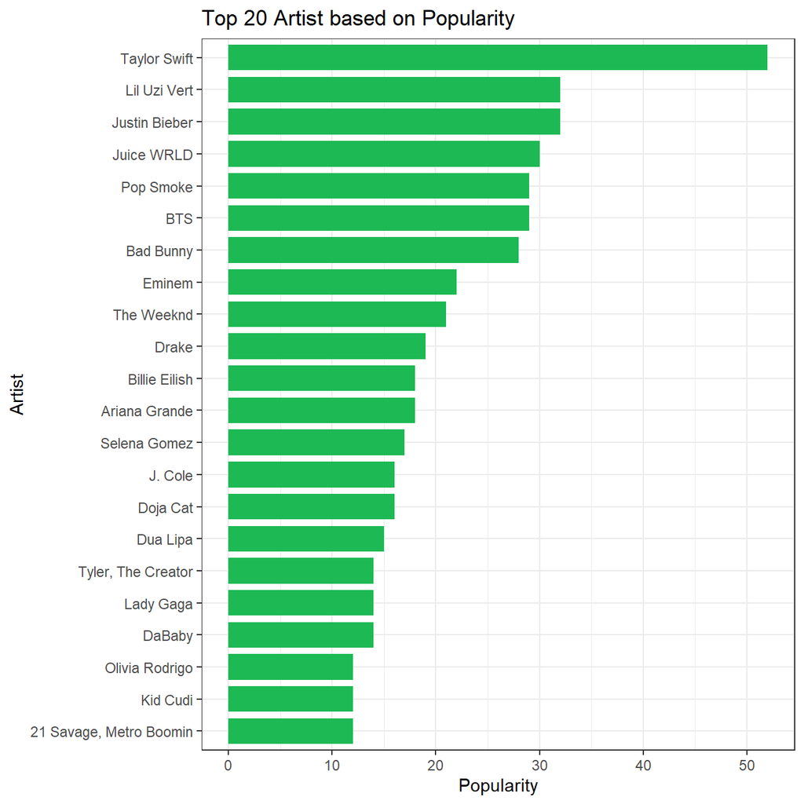

```r
#finding the top 20 artist
data1 <- spotify_data_clean %>%
  group_by(artist) %>%
  summarise(occurances = n()) %>%
  slice_max(order_by = occurances, n=20)

ggplot(data1, aes(y=fct_reorder(artist,(occurances)), x=occurances)) + geom_col(fill='#1db954', width=0.8)+
  theme(legend.position = "none") +
  labs(title = "Top 20 Artist based on Popularity",
       y = "Artist",
       x="Popularity")+
  theme_bw()
```

Distribution of songs per date

We want to understand what’s the best time to release a song. We start by looking at what’s the month in which most top songs were released. Between 2020-2021, most top songs were released in March, May and June.

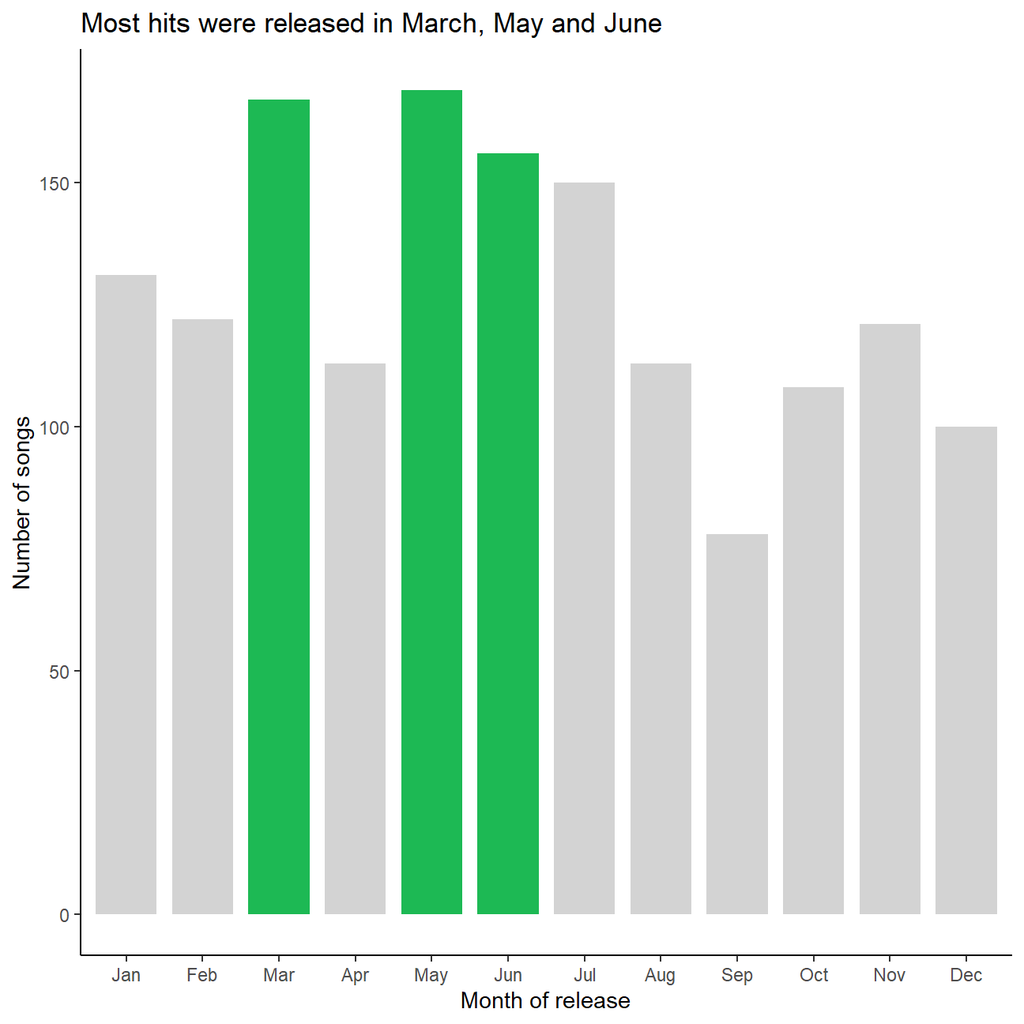

```r
monthly_distrib <- spotify_data_clean %>%
  group_by(release_month) %>%
  summarize(
    count = n()
  )

monthly_distrib <- monthly_distrib %>%
  mutate(top3 = rank(-count) %in% 1:3)

ggplot(data = monthly_distrib) +
  aes(x = release_month,
      y = count,
      fill= top3) +
  geom_bar(stat = 'identity', width=0.8) +
  labs(
    x = "Month of release",
    y = "Number of songs",
    title = "Most hits were released in March, May and June"
  ) +
  scale_fill_manual(values = c("TRUE" = "#1db954", "FALSE" = "light grey")) +
  theme_bw() +
  theme(panel.border = element_blank(),
        panel.grid.major = element_blank(),
        panel.grid.minor = element_blank(),
        axis.line = element_line(colour = "black"),
        legend.position="none")
```

Next we look at the date of the month. We can also notice that most hits were released on the days of 6th, 10th and 13th.

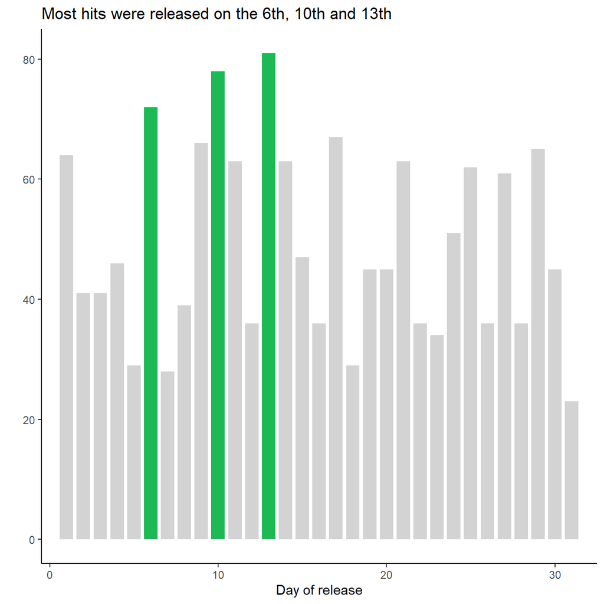

```r
day_distrib <- spotify_data_clean %>%
  group_by(release_day) %>%
  summarize(
    count = n()
  )

day_distrib <- day_distrib %>%
  mutate(top3 = rank(-count) %in% 1:3)

ggplot(data = day_distrib) +
  aes(x = release_day, y = count, fill = top3) +
  geom_bar(stat = 'identity', width=0.8, aes(xmin=1)) +
  labs(
    x = "Day of release",
    y = "",
    title = "Most hits were released on the 6th, 10th and 13th"
  ) +
  scale_fill_manual(values = c("TRUE" = "#1db954", "FALSE" = "light grey")) +
  coord_cartesian(xlim =c(1, 31)) +
  theme_bw() +
  theme(panel.border = element_blank(),
        panel.grid.major = element_blank(),
        panel.grid.minor = element_blank(),
        axis.line = element_line(colour = "black"),
        legend.position="none")
```

How long should a song be?

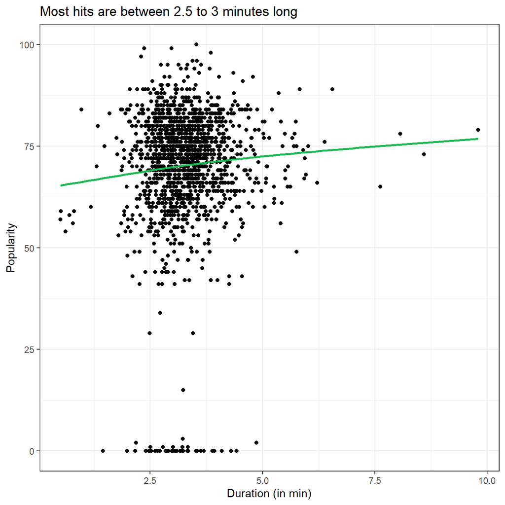

```r
#Relation between song popularity and duration

ggplot(data = spotify_data_clean) +
  aes(x = duration_min, y = popularity) +
  geom_point() +
  geom_smooth(color="#1db954", se=FALSE) +
  theme_bw() +
  labs(
    x = "Duration (in min)",
    y = "Popularity",
    title = "Most hits are between 2.5 to 3 minutes long"
  )
```

Next we want to see how chord influences the popularity of the song. Looking at the box plot below, we can see all chords have similar median values and little influence over song success.

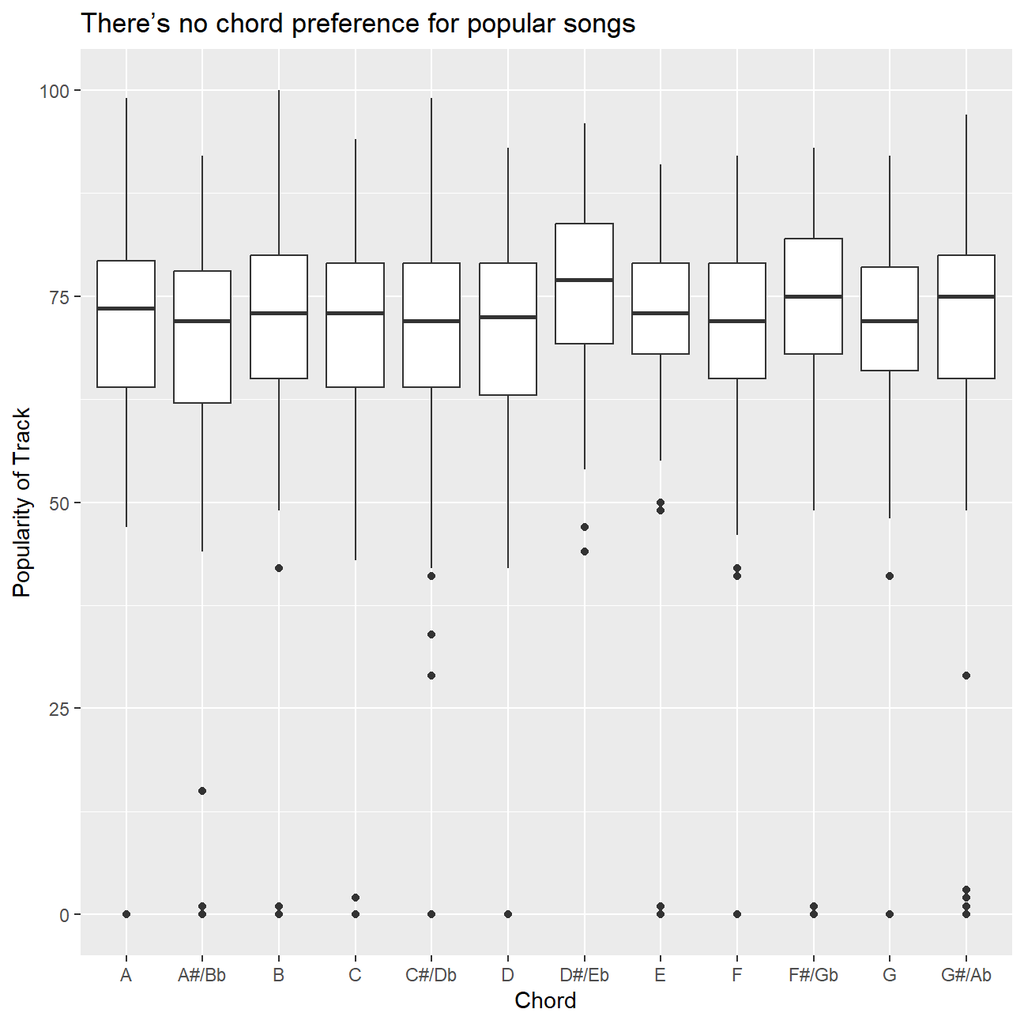

```r
ggplot(spotify_data_clean,
       aes(x=chord,
           y=popularity,
           group=chord)) +
  geom_boxplot()+
  labs(title="There’s no chord preference for popular songs",
       x='Chord',
       y='Popularity of Track')
```

There is no significant correlation between highest song position in the charts/how long it stayed in the top200 chart and its characteristics like danceability, energy and so on, so it’s unlikely that any of those are predictors of whether the song will be a hit, however, we can explore on how those metrics interact among themselves.

```r
res <- cor(spotify_data_clean %>% select(highest_charting_position, number_of_times_charted, popularity, danceability, energy, loudness, speechiness, acousticness, liveness, tempo, duration_ms,valence, streams, artist_followers))
round(res, 2)
```

```
##                           highest_charting_position number_of_times_charted
## highest_charting_position                      1.00                   -0.42
## number_of_times_charted                       -0.42                    1.00
## popularity                                    -0.16                    0.23
## danceability                                   0.03                    0.02
## energy                                         0.07                   -0.07
## loudness                                       0.04                    0.03
## speechiness                                    0.05                   -0.06
## acousticness                                  -0.01                    0.05
## liveness                                       0.01                   -0.06
## tempo                                          0.02                   -0.05
## duration_ms                                   -0.04                    0.03
## valence                                        0.05                    0.02
## streams                                       -0.30                   -0.06
## artist_followers                              -0.23                    0.03
##                           popularity danceability energy loudness speechiness
## highest_charting_position      -0.16         0.03   0.07     0.04        0.05
## number_of_times_charted         0.23         0.02  -0.07     0.03       -0.06
## popularity                      1.00         0.02   0.08     0.14       -0.04
## danceability                    0.02         1.00   0.14     0.22        0.23
## energy                          0.08         0.14   1.00     0.73        0.02
## loudness                        0.14         0.22   0.73     1.00       -0.03
## speechiness                    -0.04         0.23   0.02    -0.03        1.00
## acousticness                   -0.08        -0.31  -0.53    -0.46       -0.13
## liveness                       -0.03        -0.11   0.11     0.04        0.08
## tempo                          -0.03        -0.04   0.11     0.09        0.11
## duration_ms                     0.08        -0.10   0.05     0.06       -0.09
## valence                         0.00         0.37   0.36     0.31        0.04
## streams                         0.13        -0.08   0.01    -0.03       -0.06
## artist_followers                0.10        -0.11  -0.07    -0.04       -0.08
##                           acousticness liveness tempo duration_ms valence
## highest_charting_position        -0.01     0.01  0.02       -0.04    0.05
## number_of_times_charted           0.05    -0.06 -0.05        0.03    0.02
## popularity                       -0.08    -0.03 -0.03        0.08    0.00
## danceability                     -0.31    -0.11 -0.04       -0.10    0.37
## energy                           -0.53     0.11  0.11        0.05    0.36
## loudness                         -0.46     0.04  0.09        0.06    0.31
## speechiness                      -0.13     0.08  0.11       -0.09    0.04
## acousticness                      1.00     0.00 -0.05       -0.04   -0.10
## liveness                          0.00     1.00 -0.01        0.02    0.01
## tempo                            -0.05    -0.01  1.00       -0.01    0.06
## duration_ms                      -0.04     0.02 -0.01        1.00   -0.12
## valence                          -0.10     0.01  0.06       -0.12    1.00
## streams                           0.03     0.04  0.06        0.02    0.04
## artist_followers                  0.03    -0.01 -0.02        0.14   -0.11
##                           streams artist_followers
## highest_charting_position   -0.30            -0.23
## number_of_times_charted     -0.06             0.03
## popularity                   0.13             0.10
## danceability                -0.08            -0.11
## energy                       0.01            -0.07
## loudness                    -0.03            -0.04
## speechiness                 -0.06            -0.08
## acousticness                 0.03             0.03
## liveness                     0.04            -0.01
## tempo                        0.06            -0.02
## duration_ms                  0.02             0.14
## valence                      0.04            -0.11
## streams                      1.00             0.10
## artist_followers             0.10             1.00
```

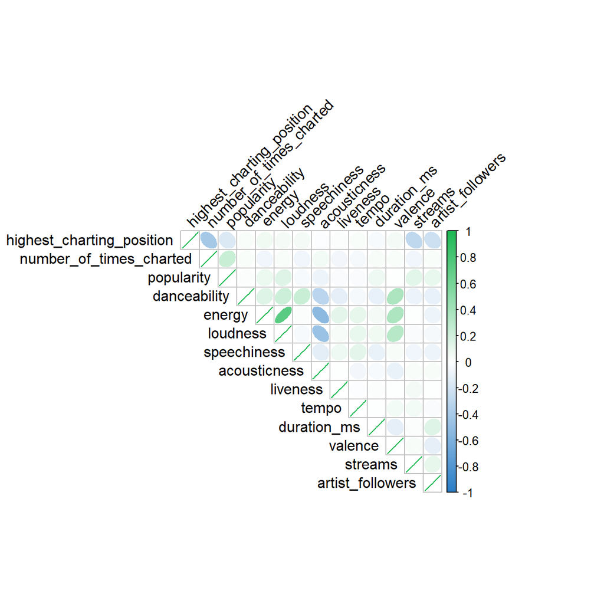

```r
corrplot(res, method = "ellipse", type = "upper", color = "green", tl.col = 'black',  tl.srt = 45, col=colorRampPalette(c("#287DC7","white","#1DB954"))(200))
```

The resulting graphs show that loud songs tend to be also the most energetic ones. Acoustic ones, on the other hand, tend to be quieter, less energetic and harder to dance to. Finally, there is positive correlation between how emotional is the song and its danceability, loudness and energy - so the most intense songs might be clubs’ biggest hits.

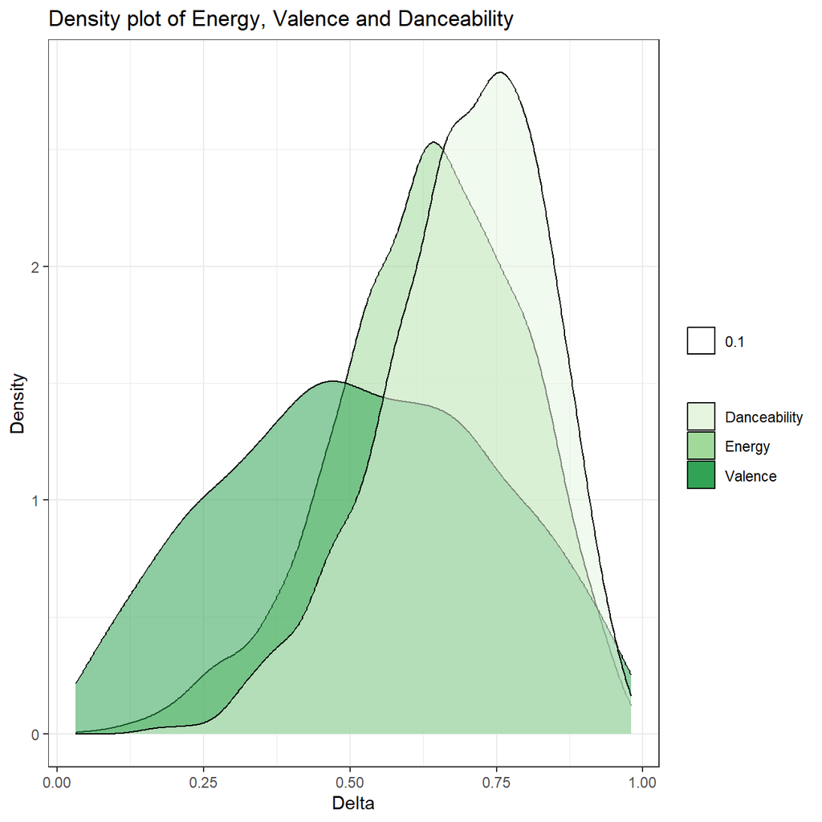

```r
ggplot(spotify_data_clean) +
    geom_density(aes(energy,
                     fill ="Energy",
                     alpha = 0.1)) +
    geom_density(aes(valence,
                     fill ="Valence",
                     alpha = 0.1)) +
    geom_density(aes(danceability,
                     fill ="Danceability",
                     alpha = 0.1)) +
    scale_x_continuous(name = "Delta") +
    scale_y_continuous(name = "Density") +
    ggtitle("Density plot of Energy, Valence and Danceability") +
    theme_bw()  +
    theme(legend.title=element_blank()) +
    scale_fill_brewer(palette="YIGn")
```